# Short Read Alignment

September 2019

## Differential Gene Expression Analysis Workflow

[figure not shown]

## Alignment

AIM: Given a reference sequence and a set of short reads, align each read to the reference sequence finding the most likely origin of the read sequence.

[figure not shown]

## Alignment - Gap aware alignment

[figure not shown]

Aligners: STAR, HISAT2

## SAM format

**S**equence **A**lignment/**M**ap (SAM) format is the standard format for files containing aligned reads.

Definition of the format is avaiable at https://samtools.github.io/hts-specs/SAMv1.pdf.

Two main parts:

- Header
  - contains meta data (source of the reads, reference genome, aligner, etc.)
  - Header lines start with “@”.
  - Header fields have standardized two-letter codes
- Alignment section
  - 1 line for each alignment
  - Contains details of alignment position, mapping, base quality etc.
  - 11 required fields, but other content may vary depending on aligner and other tools used to the create the file

## SAM format - header

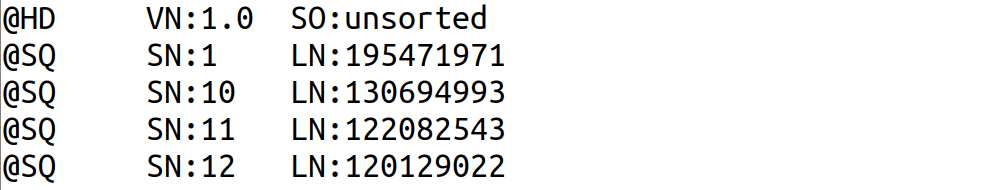

……………………..  
……………………..

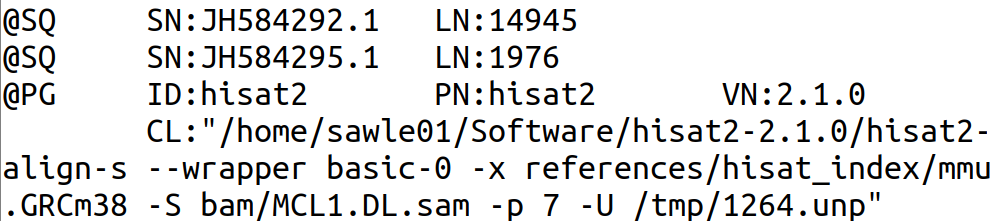

## SAM format - alignment

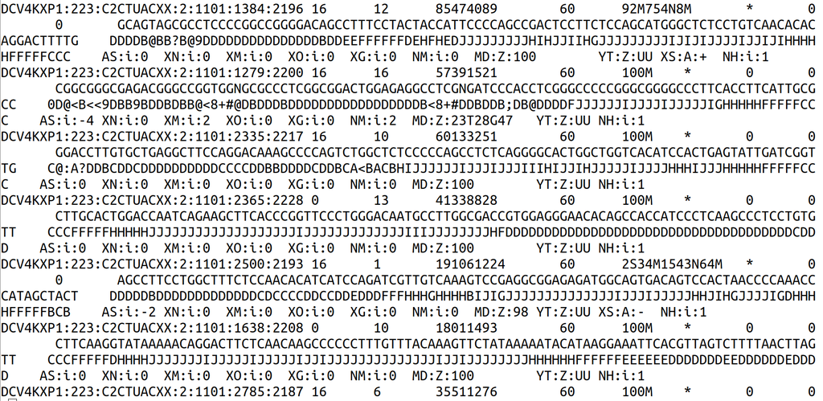

## SAM format - alignment

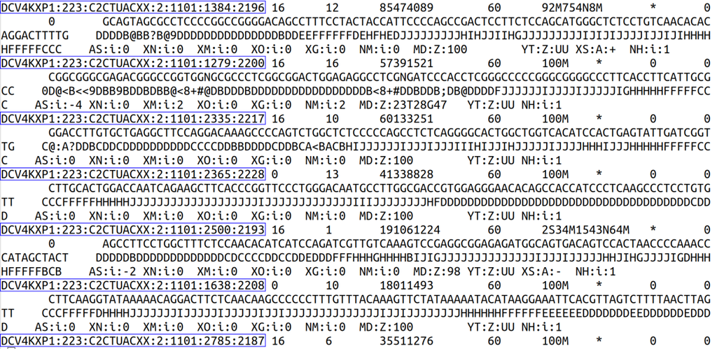

## SAM format - alignment

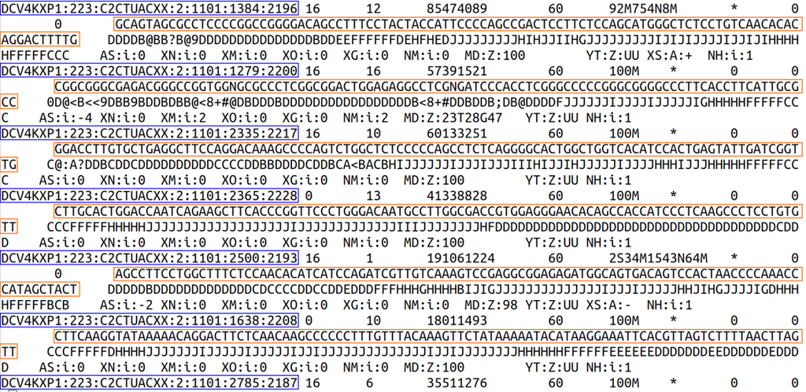

## HISAT2

Fast and good performance in published benchmark tests.

First need to generate an index for the reference genome with the `hisat2-build` command

Indexing is where all the work takes place and so is computationally intensive

Then we can align reads to the genome with `hisat2`

## SAM format - alignment

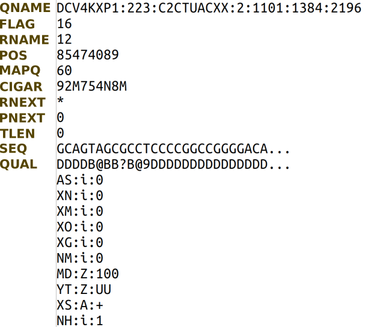

## SAM format - alignment

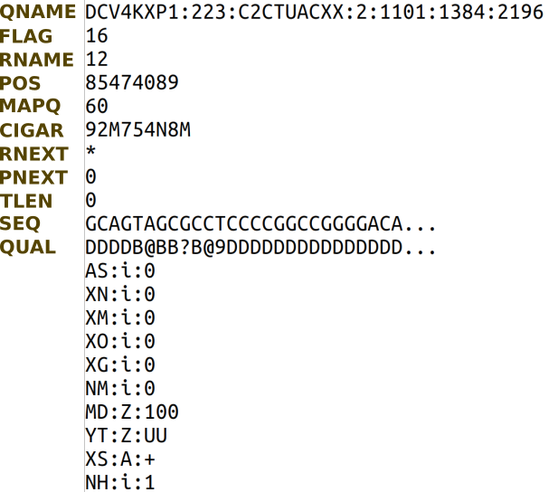

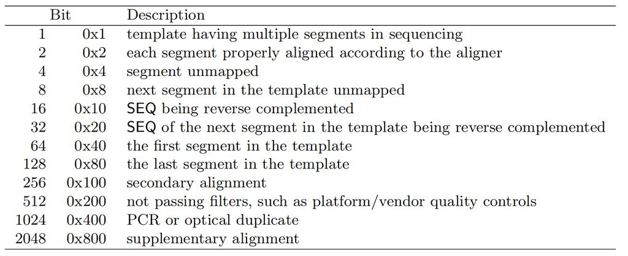

[Explain SAM flags](https://broadinstitute.github.io/picard/explain-flags.html)